# Projekt 1 etap 2

Patrycja Faszczewska, Adrianna Wlazło

11 listopada 2016

W drugim etapie najpierw zbudujemy klasyfikatory na zbiorze treningowym , natomiast w kolejnym kroku porównamy jakość przeprowadzonych klasyfikacji.

W pierwszej fazie projektu uzyskałyśmy ok.30 zmiennych, które uznałyśmy za istotne i które posłużą nam do budowania klasyfiatorów w celu oceny śmiertelności wśród chorych. Zmienne te zapisujemy na wektorze wybrane. Ponadto wybieramy zbiór treningowy oraz testowy, które posłużą nam do przeprowadzenia analizy jakości budowanych klasyfikacji. (Korzystamy z funkcji `createDataPartition`, gdyż bierze ona pod uwagę strukturę zbioru obserwacji, tzn. zachowuje stosunek osób które przeżyły oraz umarły w tworzonych zbiorach)

```r
library("caret")
inTrain<- createDataPartition(y=cancer$death1y,p=0.75, list=FALSE)
train <- cancer[inTrain,]

wybrane <- c("smierc"
             ,"SLC17A9", "PLAUR", "LRRC6", "CLEC5A", "TBL1XR1", "BHLHE40",
             "CTSB", "LSP1","NRG1", "AQP9", "CSNK1D", "HK3", "ACTR3C","age", "SLC11A1",
             "TM7SF4", "CTF1", "GPNMB", "MLPH", "STC1", "C8orf58", "CPPED1", "CTSD",
             "MAP2K3", "NCF2","TNFSF14","ZC3H12A", "LILRB3", "SLC6A6")

wybrane2<-c("SLC17A9", "PLAUR", "LRRC6", "CLEC5A", "TBL1XR1", "BHLHE40",
             "CTSB", "LSP1","NRG1", "AQP9", "CSNK1D", "HK3", "ACTR3C","age", "SLC11A1","TM7SF4", "CTF1", "GPNMB", "MLPH", "STC1", "C8orf58", "CPPED1", "CTSD", "MAP2K3", "NCF2","TNFSF14","ZC3H12A", "LILRB3", "SLC6A6")
```

## Klasyfikatory

1.Pierwszym klasyfikatorem, który zbudujemy będzie regresja logistyczna, którą wywołamy przy użyciu funkcji `glm`.

```r
r <- glm(smierc~.,train[,wybrane], family="binomial")
summary(r)
```

```
##
## Call:
## glm(formula = smierc ~ ., family = "binomial", data = train[,
##     wybrane])
##
## Deviance Residuals:
##      Min        1Q    Median        3Q       Max
## -2.38649  -0.47809   0.00658   0.36935   2.69892
##
## Coefficients:
##              Estimate Std. Error z value Pr(>|z|)
## (Intercept) -2.246574   4.670855  -0.481  0.63053
## SLC17A9     -1.006587   0.899338  -1.119  0.26303
## PLAUR        0.440466   1.198096   0.368  0.71314
## LRRC6       -0.385401   0.506808  -0.760  0.44699
## CLEC5A       0.039280   0.507469   0.077  0.93830
## TBL1XR1     -1.393317   1.766407  -0.789  0.43024
## BHLHE40     -1.027511   0.727945  -1.412  0.15809
## CTSB         1.152252   1.722167   0.669  0.50345
## LSP1         0.372158   0.796863   0.467  0.64048
## NRG1         0.807794   0.276196   2.925  0.00345 **
## AQP9         0.219684   0.669950   0.328  0.74298
## CSNK1D       9.241963   2.898784   3.188  0.00143 **
## HK3         -0.990331   0.744148  -1.331  0.18325
## ACTR3C       0.897528   0.493541   1.819  0.06898 .
## age         -0.010420   0.040692  -0.256  0.79789
## SLC11A1      0.440366   1.026179   0.429  0.66783
## TM7SF4       0.020578   0.361105   0.057  0.95456
## CTF1        -0.005848   0.811446  -0.007  0.99425
## GPNMB        0.951651   0.599263   1.588  0.11228
## MLPH         0.073669   0.315417   0.234  0.81533
## STC1        -0.303062   0.488327  -0.621  0.53485
## C8orf58      2.823818   1.618845   1.744  0.08110 .
## CPPED1       0.099037   0.833084   0.119  0.90537
## CTSD        -2.964109   1.924481  -1.540  0.12351
## MAP2K3       1.475658   1.222569   1.207  0.22743
## NCF2         0.455526   1.570506   0.290  0.77178
## TNFSF14      0.202766   0.452867   0.448  0.65434
## ZC3H12A      0.034871   0.943660   0.037  0.97052
## LILRB3       0.618402   0.598823   1.033  0.30175
## SLC6A6       0.804847   0.599960   1.342  0.17976
## ---
## Signif. codes:  0 '***' 0.001 '**' 0.01 '*' 0.05 '.' 0.1 ' ' 1
##
## (Dispersion parameter for binomial family taken to be 1)
##
##     Null deviance: 131.687  on 94  degrees of freedom
## Residual deviance:  55.219  on 65  degrees of freedom
## AIC: 115.22
##
## Number of Fisher Scoring iterations: 7
```

2.Dzięki funkcji summary możemy obejrzeć wyniki przeprowadzoej regresji. Ostatnia z kolumn opisujących zmienne objaśniające mówi o istotności każdej ze zmiennych. Jak widzimy większość zmiennych model uznaje za niestotne, więc możemy próbować poprawiać przedstawiony klasyfikator, aby optymalnie dobrał liczbę zmiennych użytych do modelu. Zrobimy to przy użyciu funkcji `step`, która kolejno będzie konstruować model stopniowo dodając (odrzucając) kolejne zmienne.

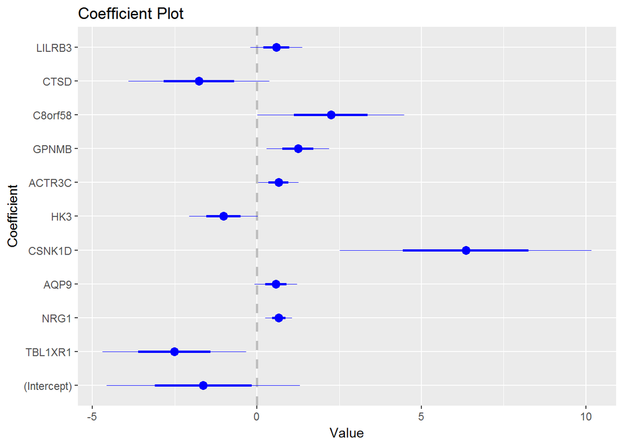

```r
r1<-step(r,method="backward")

r2<-step(r,method="forward")

library("coefplot")
coefplot(r1,lwdInner=1,lwdOuter=0.1, color="blue")
```

Zamieszczony powyżej wykres przedstawia wartości współczynników otrzymane w poprawionym modelu regresji wraz z przedziałami ufności (zewnętrznymi i wewnętrznymi). Jak widzimy model ten składa się z ok. 10 zmiennych.

3. Kolejnym klasyfikatorem, który może posłużyć nam do analizy jest naiwny klasyfikator Bayesowski. Model ten ma jednak pewne ograniczenia : zakłada on bowiem, że łączna gestość jest iloczynem gęstości brzegowych. Zapominając na chwilę o tej “ułomności” modelu konstruujemy go przy pomocy funkcji `NaiveBayes` z pakietu `klaR`.

```r
library("klaR")
NB<-NaiveBayes(smierc~.,data=train[,wybrane])
```

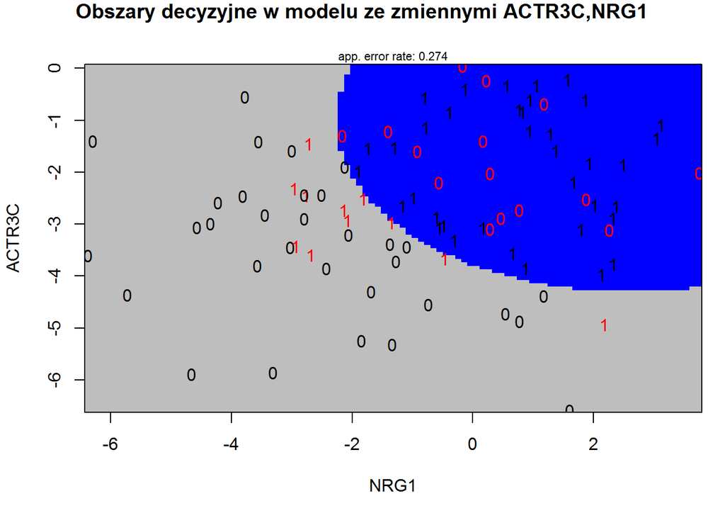

```r
library("klaR")


partimat(smierc~ACTR3C+NRG1,data=cancer[inTrain,wybrane],method="naiveBayes",main="Obszary decyzyjne w modelu ze zmiennymi ACTR3C,NRG1",col.correct = "black", col.wrong = "red",pch=15,image.colors=c("grey","blue1"))
```

Kolorem szarym oznaczony został obszar odpowiadający klasyfikacji pacjentów, którzy przeżyją pierwszy rok leczenia zgodnie z modelem naiwnego klasyfikatora Bayesa zbudowanym na zmiennych ACTR3C,NRG1. Natomiast kolorem czerwonym oznaczone zostały obserwacje błędnie trafiające we wskazane im obszary decyzyjne.

4. Kolejnym narzędziem pomocnym w klasyfikacji są drzewa decyzyjne. Są one łatwe w interpetacji, co ułatwia analizę otrzymanych wyników. Charakteryzują się one małą stabilnością, więc można spróbować kontrolować je przy pomocy ustawienia głębokości konstruowanego drzewa, bądź też definiowania warunku stopu. Zdecydowałyśmy się dopuszczać głębokość drzewa na poziomie 10 oraz podział decyzji w drzewie dla każdej cechy, której p-wartość jest mniejsza niż 0.25.

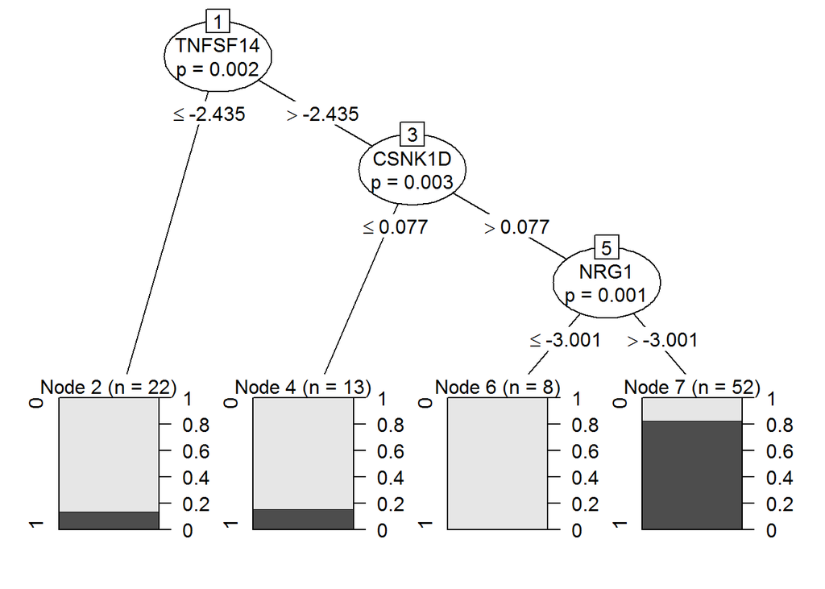

```r
library("party")
drzewo <- ctree(smierc~., data=train[,wybrane], controls= ctree_control(maxdepth=10,testtype = "Bonferroni",mincriterion = 0.75))
plot(drzewo)
```

5. Kolejnym klasyfikoterem, który skonstruujemy są lasy losowe, gdyż charakteryzują się one większą stabilnością, zatem powinny być “lepszym” odpowiednikiem drzew decyzyjnych. Jest do konstruowanie drzew decyzyjnych na losowych replikacjach zbioru, tak więc aby odtworzyć wyniki używamy funkcji `set.seed`.

```r
set.seed(1)
library("randomForest")
laslos<-randomForest(smierc~.,data=train[,wybrane],importance=TRUE,proximity=TRUE)
laslos
```

```
##
## Call:
##  randomForest(formula = smierc ~ ., data = train[, wybrane], importance = TRUE,      proximity = TRUE)
##                Type of random forest: classification
##                      Number of trees: 500
## No. of variables tried at each split: 5
##
##         OOB estimate of  error rate: 24.21%
## Confusion matrix:
##    0  1 class.error
## 0 33 14   0.2978723
## 1  9 39   0.1875000
```

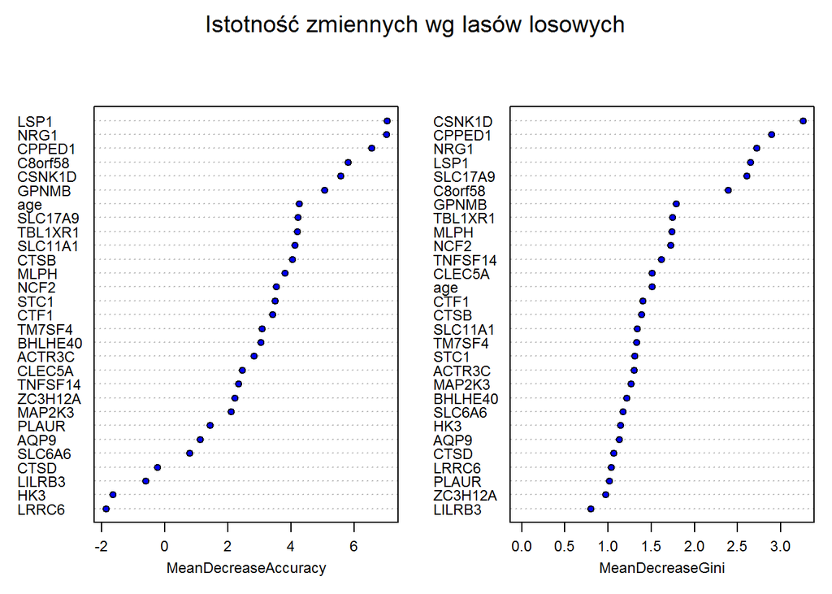

```r
varImpPlot(laslos,pch=21,bg="blue",cex=0.75,main="Istotność zmiennych wg lasów losowych")
```

## Tablice kontyngencji

Dla regresji logistycznej:

```r
smierc<-cancer[-inTrain,wybrane]$smierc
predykcja1 <- predict(r, cancer[-inTrain,wybrane],type="response")
predykcja1 <- round(predykcja1,digits=0)
table(predykcja1,smierc, dnn=list("predykcja regresji logistycznej","śmierć"))
```

```
##                                śmierć
## predykcja regresji logistycznej  0  1
##                               0 10  3
##                               1  5 12
```

Dla regresji logistycznej poprawionej metodą backward:

```
##                         śmierć
## predykcja rlm (backward)  0  1
##                        0 11  2
##                        1  4 13
```

Dla regresji logistycznej poprawionej metodą forward:

```
##                        śmierć
## predykcja rlm (forward)  0  1
##                       0 11  2
##                       1  4 13
```

Dla drzewa:

```
##                 śmierć
## predykcja drzewa  0  1
##                0  6  5
##                1  9 10
```

Dla lasu losowego:

```
##               śmierć
## predykcja lasu  0  1
##              0  9  5
##              1  6 10
```

Z tablic tych mozemy odczytać liczbę błędnie sklasyfikowanych prób. Jest to suma elementów poza przekątną tablicy. Pozwala to na porównanie klasyfikatorów w zależności od stosunku błędnie zaklasyfkowanych obserwacji.

## Krzywe ROC

Istnieje jednak wiele innych miar błędu predykcji biorących pod uwagę między innymi czułość modelu (opisuje jaki procent zmarłych po roku zostaje poprawnie sklasyfikowanych), czy też specyficzność (opisuje jaki procent osób, które przeżyły pierwszy rok po leczeniu zostaje poprawnie sklasyfikowana). Od dobrego klasyfikatora oczekujemy możliwie wysokiej czułości i specyficzności.

Aby zilustrować te miary użyjemy krzywej ROC, którą będziemy porównywać między klasyfikatorami.

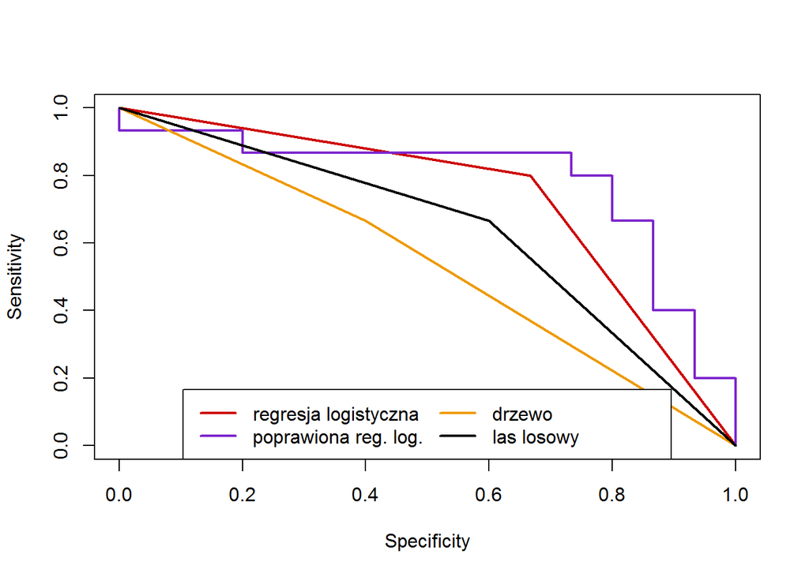

Wykres ten ma bardzo wygodną interpretację - im większe pole pod krzywą ROC, tym lepszy jest klasyfikator. Zatem zgodnie z tą zasadą regresja po raz kolejny wypada najlepiej w porównaniu z pozostalymi klasyfikatorami.

Zbadajmy zatem pole pod krzywą replikując 100 razy losowanie zbioru testowego i porównajmy średnie pola otrzymane w krzywych ROC dla każdego z klasyfikatorów.

```
## Średnie pola pod wykresem krzywej ROC:
##  0.7750222   Poprawiona regresja logistyczna
##  0.5443333   Naiwny klasyfikator Bayesowski
##  0.5483333   Drzewo
##  0.562   Las losowy
```

## K-fold cross-walidacja

Jakość klasyfikotora możemy również badać porównując błąd cross-walidacji (Będziemy korzystać z 10-fold cv). Na każdym z 10-ciu podzbiorów sprawdzamy trafność predykcji modelu zbudowanego na pozostałych zbiorach. Następnie uśredniamy ten błąd aby porównywać kolejne klasyfikatory.

```r
set.seed(1313)
fold <- createFolds(cancer$smierc, k = 10)

errors2 <- lapply(fold, function(x) {
  model<-step(glm(smierc~.,cancer[-x,wybrane],family="binomial"),method="backward")
  predykcja1 <- predict(model, cancer[x,wybrane],type="response")
  p <- round(predykcja1,digits=0)
  c<- as.numeric(cancer[x, "smierc"])-1
  mean(abs(p-c))
})

mean(as.numeric(errors2))
```

Analogicznie przeprowadzamy cross-walidację dla innych modeli.

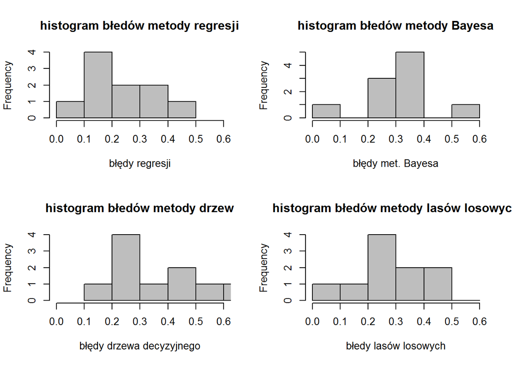

```
## Średnie błędy klasyfikatorów:
##  0.224359   Poprawiona regresja logistyczna
##  0.2987179   Naiwny klasyfikator Bayesowski
##  0.3673077   Drzewo
##  0.2839744   Las losowy
```

```r
set.seed(1313)
fold <- createFolds(cancer$smierc, k = 125)

errors2 <- lapply(fold, function(x) {
  model<-step(glm(smierc~.,cancer[-x,wybrane],family="binomial"),method="backward")
  predykcja1 <- predict(model, cancer[x,wybrane],type="response")
  p <- round(predykcja1,digits=0)
  c<- as.numeric(cancer[x, "smierc"])-1
  mean(abs(p-c))
})

mean(as.numeric(errors2))
```

Analogicznie przeprowadzamy cross-walidację dla innych modeli.

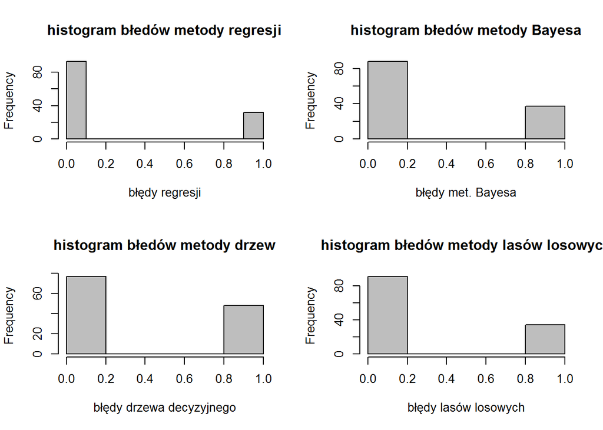

```
## Średnie błędy klasyfikatorów:
##  0.256   Poprawiona regresja logistyczna
##  0.296   Naiwny klasyfikator Bayesowski
##  0.384   Drzewo
##  0.272   Las losowy
```

W drugim etapie skupiłyśmy się na prezentacji następujących klasyfikatorów: regresja, regresja poprawiona funkcją step, naiwny klasyfikator Bayesowski, drzewa losowe oraz lasy losowe.Porównałyśmy wymienione klasyfikatory analizując tablice kontyngencji, średnie pole pod krzywą (przy 100-krotnym losowaniu zbiorów treningowych) jak również błędy otrzymane w krosswalidacji (10-fold oraz leave-one- out). Miary te skłaniają nas do wyboru poprawionej regresji jako modelu najlepiej przewidującego stan pacjenta po roku spośród przedstawionych wyżej sposobów klasyfikacji. Ze względu na mało satysfakcjonujące wyniki, wynikające chociażby z możliwości przeuczenia modelu, w następnym etapie użyjemy bardziej zaawansowanych modeli z nadzieją na osiągnięcie lepszych rezultatów.